# The Value of a College Education

Nick Hass

1/26/2022

# Homework 1

## Analysis Questions

#### 1. Create exploratory plots and calculate summary statistics from the data. Comment on any potential relationships you see from these exploratory plots.

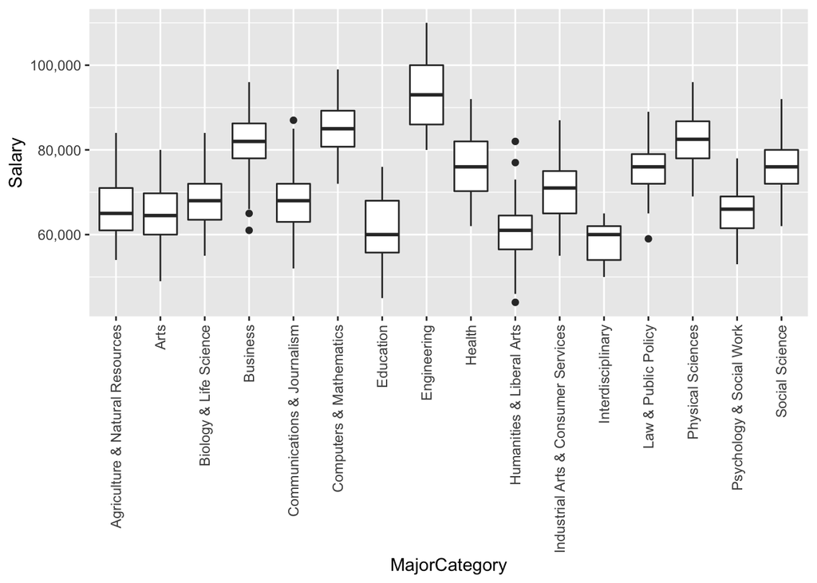

```r
salary <- read.csv("salary.csv")
#head(salary)

salaryByMajor <- salary %>%
  group_by(MajorCategory) %>%
  summarise(AvgSalary = mean(Salary))

# Plot a boxplot of the salary distribution for each major
ggplot(data = salary, mapping = aes(x = MajorCategory, y = Salary)) +
  geom_boxplot() +
  theme(axis.text.x = element_text(angle = 90, vjust = 0.5, hjust=1)) +
  scale_y_continuous(labels = scales::comma)
```

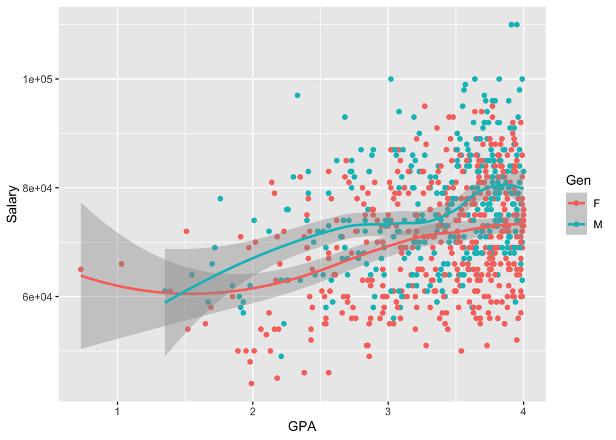

```r
salaryByGPA <- salary %>%
  group_by(GPA) %>%
  summarise(AvgSalaryByGPA = mean(Salary))

ggplot(data = salary, mapping = aes(x = GPA, y = Salary, colour = Gen)) +
  geom_point() + geom_smooth()
```

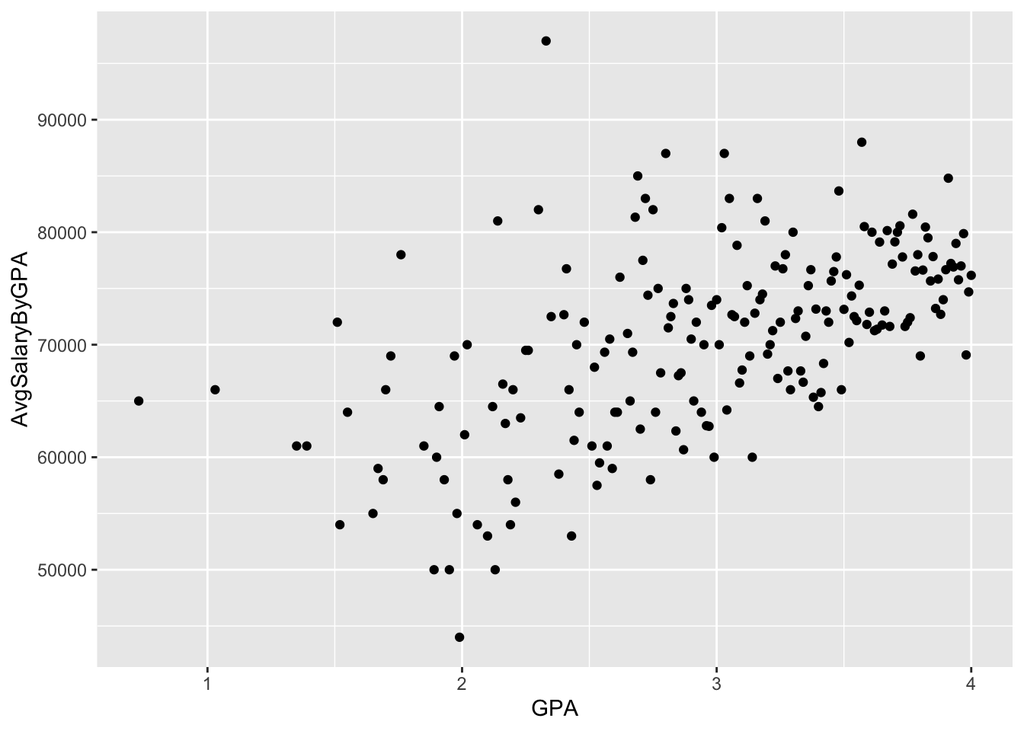

```r
ggplot(data = salaryByGPA, mapping = aes(x = GPA, y = AvgSalaryByGPA)) +
  geom_point()
```

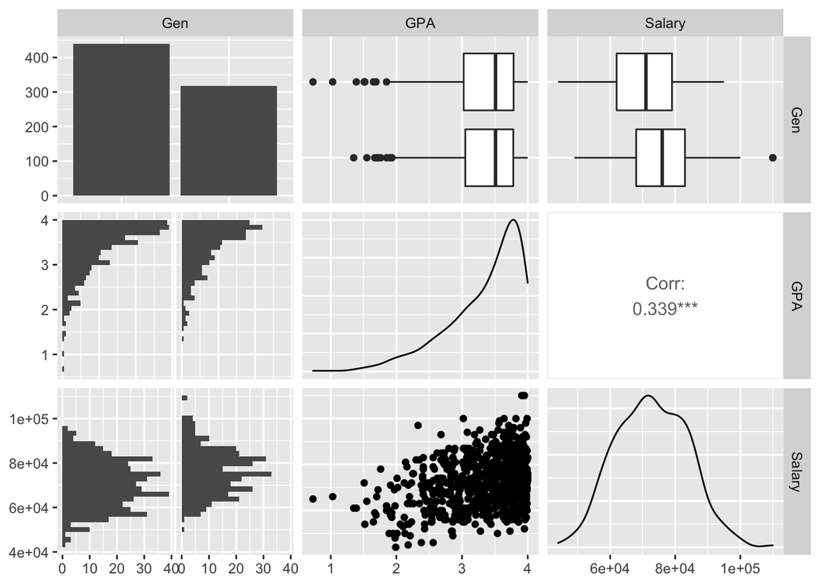

```r
newSalary <- salary[,-1]
response <- salary[1]
newerSalary <- newSalary[-1]

newererSalary <- cbind(newerSalary, response)
GGally::ggpairs(newererSalary)
```

Relationships I see from EDA: Salaries are very distinct when grouped by `MajorCategory`. From the scatterplot of GPA by Average Salary (by gpa), it looks like there is a positive correlation between GPA and Average Salary. It looks like Males make on average, more money than females.

#### 2. Write down a linear regression model (in matrix and vector form) in terms of parameters. Explain the meaning of any parameters in your model. Explain how statistical inference for your model can be used to answer the effect of major choice and identify any gender discrimination.

$Y = X\beta + \epsilon, \hspace{0.25cm} \epsilon \sim \text{MVN(0,} \sigma^2)$

X is the Design matrix with 1s on the first column $\beta$ is a vector of the coefficients for each explanatory variable $\epsilon$ is the random vector

Statistical inference can be used to answer the effect of major choice by testing if their is a difference between expected salary by major choice and using a confidence interval to see how large that difference is.

Statistical inference can be used to identify any gender discrimination by determining if the slope for expected salaries are different amongst the two genders.

#### 3. Using first principles (i.e. DON’T use lm() but you can check your answer with lm()), calculate beta hat and report the estimates in a table. Interpret the coefficient for 1 categorical explanatory variable and the coefficient for GPA. Also calculate the estimate of the residual variance (or standard deviation) and R2 (you can use lm() to get R2).

```r
X <- model.matrix(Salary~., data = salary)
P <- 17 # GPA + gender + 15 major categories
n <- dim(salary)[1]

beta_hat <- solve(t(X)%*%X) %*% t(X) %*% salary$Salary

resid_variance <- t(salary$Salary - X %*% beta_hat) %*% (salary$Salary - X %*% beta_hat) / (n-P-1)
salary.lm <- lm(Salary ~ ., data=salary)

print(lm(Salary ~ ., data=salary))
```

```
##
## Call:
## lm(formula = Salary ~ ., data = salary)
##
## Coefficients:
##                                      (Intercept)
##                                          46673.0
##                                MajorCategoryArts
##                                          -2551.6
##              MajorCategoryBiology & Life Science
##                                            769.1
##                            MajorCategoryBusiness
##                                          14282.1
##         MajorCategoryCommunications & Journalism
##                                            114.6
##             MajorCategoryComputers & Mathematics
##                                          17936.9
##                           MajorCategoryEducation
##                                          -5894.8
##                         MajorCategoryEngineering
##                                          24406.2
##                              MajorCategoryHealth
##                                           8670.2
##           MajorCategoryHumanities & Liberal Arts
##                                          -5972.6
## MajorCategoryIndustrial Arts & Consumer Services
##                                           2823.5
##                   MajorCategoryInterdisciplinary
##                                          -7397.0
##                 MajorCategoryLaw & Public Policy
##                                           7664.9
##                   MajorCategoryPhysical Sciences
##                                          17118.3
##            MajorCategoryPsychology & Social Work
##                                          -1979.7
##                      MajorCategorySocial Science
##                                           7923.4
##                                             GenM
##                                           5931.6
##                                              GPA
##                                           5488.7
```

```r
print(beta_hat)
```

```
##                                                        [,1]
## (Intercept)                                      46672.9855
## MajorCategoryArts                                -2551.6387
## MajorCategoryBiology & Life Science                769.1305
## MajorCategoryBusiness                            14282.1484
## MajorCategoryCommunications & Journalism           114.6014
## MajorCategoryComputers & Mathematics             17936.9081
## MajorCategoryEducation                           -5894.8466
## MajorCategoryEngineering                         24406.2278
## MajorCategoryHealth                               8670.1623
## MajorCategoryHumanities & Liberal Arts           -5972.5852
## MajorCategoryIndustrial Arts & Consumer Services  2823.5261
## MajorCategoryInterdisciplinary                   -7396.9963
## MajorCategoryLaw & Public Policy                  7664.8538
## MajorCategoryPhysical Sciences                   17118.2762
## MajorCategoryPsychology & Social Work            -1979.6997
## MajorCategorySocial Science                       7923.3790
## GenM                                              5931.6270
## GPA                                               5488.7368
```

```r
print(resid_variance)
```

```
##          [,1]
## [1,] 29226669
```

```r
sigma(salary.lm)^2
```

```
## [1] 29226669
```

```r
summary(salary.lm)$r.squared
```

```
## [1] 0.7637316
```

```r
# math and computers, male, 3.0 gpa prediction
# pred <- matrix(c(1,0,0,0,0,1,0,0,0,0,0,0,0,0,0,0,1,3.0), ncol=1)
# t(pred) %*% beta_hat
```

Q: Interpret the coefficient for 1 categorical explanatory variable and the coefficient for GPA.

A: Since the base case is for a female, holding everything else constant (major and GPA), a male can expect Salary to go up by 5931.60 dollars on average.

Q: Explain the coefficient for the GPA

A: Holding everything constant (major and gender), as GPA increases by 1, the average salary will increase by 5488.7 dollars.

Q: Also calculate the estimate of the residual variance (or standard deviation) and R2 (you can use lm() to get R2).

A: R squared is 0.7637316

#### 4. One common argument is that some disciplines have greater biases (in terms of lower salaries) towards women than others. To verify this, check for interactions between major and gender by (i) drawing side-by-side boxplots of salary for each major category and gender combination and (ii) running an appropriate hypothesis test (either t or F) to check for significance. Comment on potential gender discrimination from your boxplot. For your hypothesis test, state your hypotheses, report an appropriate test statistic, p-value and give your conclusion.

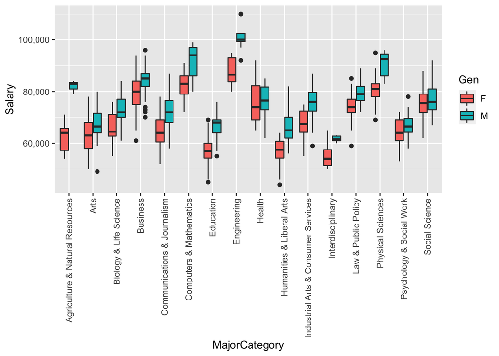

```r
# Plot side-by-side boxplots of the salary distribution for each major and gender combination
ggplot(data = salary, mapping = aes(x = MajorCategory, y = Salary, fill= Gen)) +
  geom_boxplot() +
  theme(axis.text.x = element_text(angle = 90, vjust = 0.5, hjust=1)) +
  scale_y_continuous(labels = scales::comma)
```

```r
# Hypothesis test to check for significance (F test)
full.lm <- salary.lm
reduced.lm <- lm(Salary ~ MajorCategory + GPA, data = salary)
anova(full.lm,reduced.lm)
```

```
## Analysis of Variance Table
##
## Model 1: Salary ~ MajorCategory + Gen + GPA
## Model 2: Salary ~ MajorCategory + GPA
##   Res.Df        RSS Df   Sum of Sq      F    Pr(>F)
## 1    738 2.1569e+10
## 2    739 2.7963e+10 -1 -6393530395 218.76 < 2.2e-16 ***
## ---
## Signif. codes:  0 '***' 0.001 '**' 0.01 '*' 0.05 '.' 0.1 ' ' 1
```

```r
anova(full.lm,reduced.lm)["Pr(>F)"]
```

```
##      Pr(>F)
## 1
## 2 < 2.2e-16 ***
## ---
## Signif. codes:  0 '***' 0.001 '**' 0.01 '*' 0.05 '.' 0.1 ' ' 1
```

```r
bigger.lm <- lm(Salary ~ MajorCategory + GPA + Gen + Gen:MajorCategory, data = salary)
anova(bigger.lm, full.lm)
```

```
## Analysis of Variance Table
##
## Model 1: Salary ~ MajorCategory + GPA + Gen + Gen:MajorCategory
## Model 2: Salary ~ MajorCategory + Gen + GPA
##   Res.Df        RSS  Df   Sum of Sq      F    Pr(>F)
## 1    723 1.9780e+10
## 2    738 2.1569e+10 -15 -1789058098 4.3595 7.161e-08 ***
## ---
## Signif. codes:  0 '***' 0.001 '**' 0.01 '*' 0.05 '.' 0.1 ' ' 1
```

Q: Comment on potential gender discrimination from your boxplot. For your hypothesis test, state your hypotheses, report an appropriate test statistic, p-value and give your conclusion.

I conducted another F test to test whether there was interaction between Gender and Major category and found that there was (because p-value < 7.161e-08).

#### 5. The validity of the tests from #4 depend on the validity of the assumptions in your model (if your assumptions are violated then the p-values are likely wrong). Create graphics and/or run appropriate hypothesis tests to check the L-I-N-E assumptions associated with your multiple linear regression model including any interactions you found in #4. State why each assumption does or does not hold for the salary data.

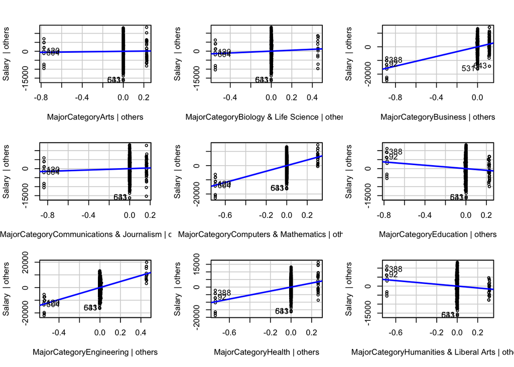

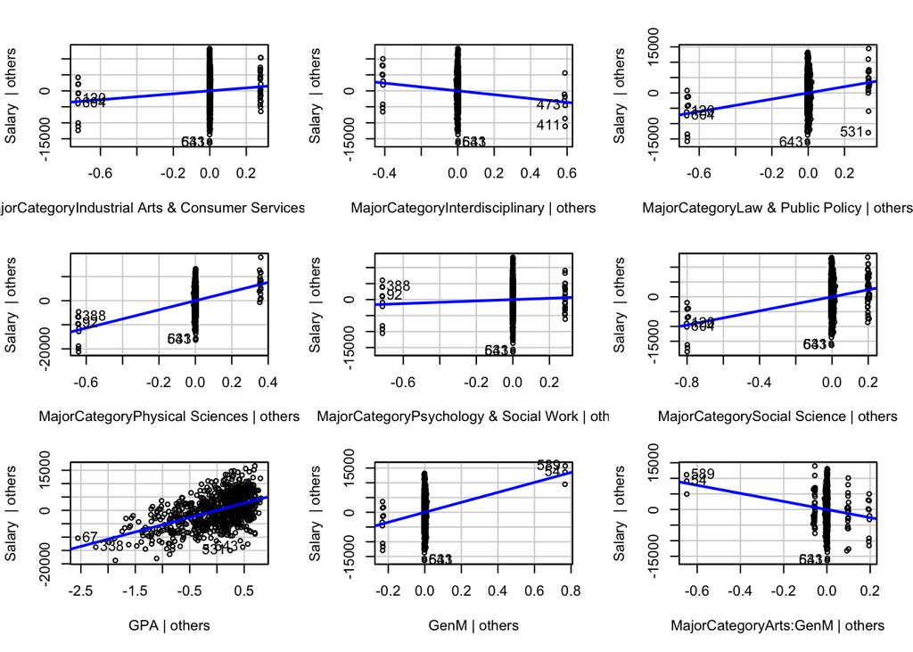

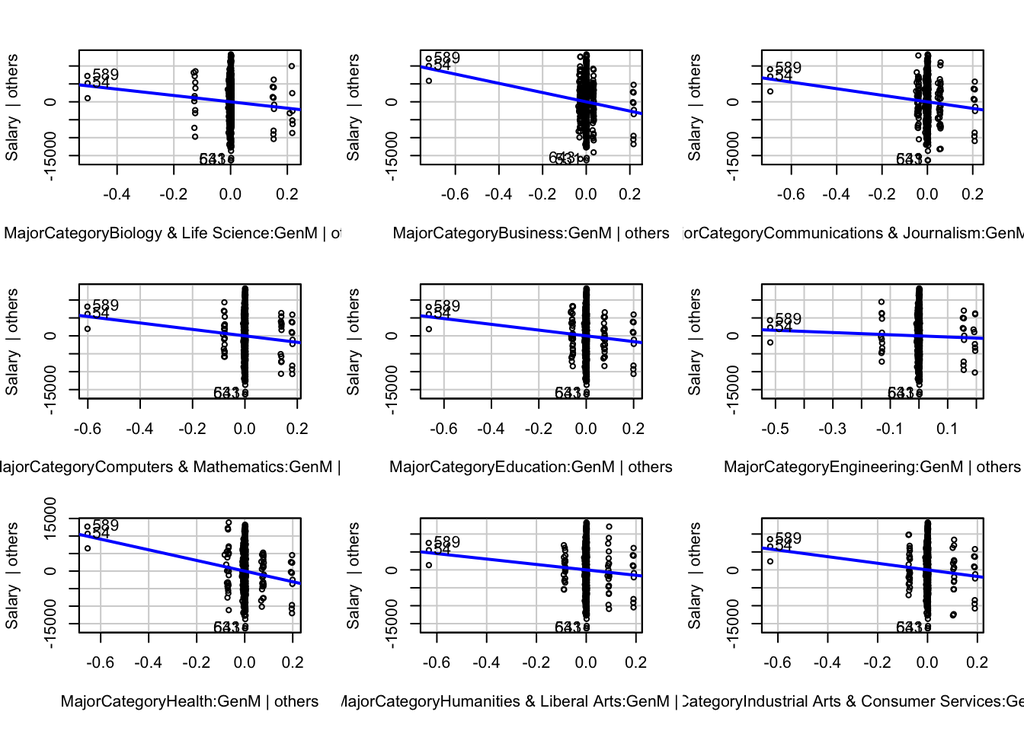

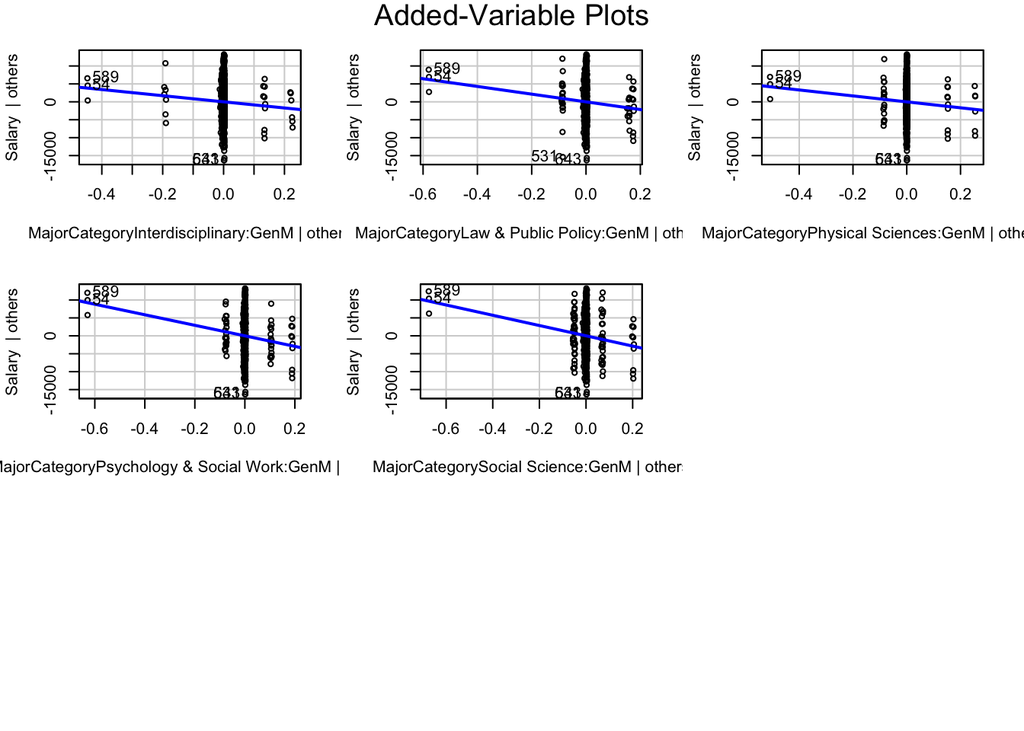

```r
# Linearity - Added variable plots
car::avPlots(bigger.lm)
```

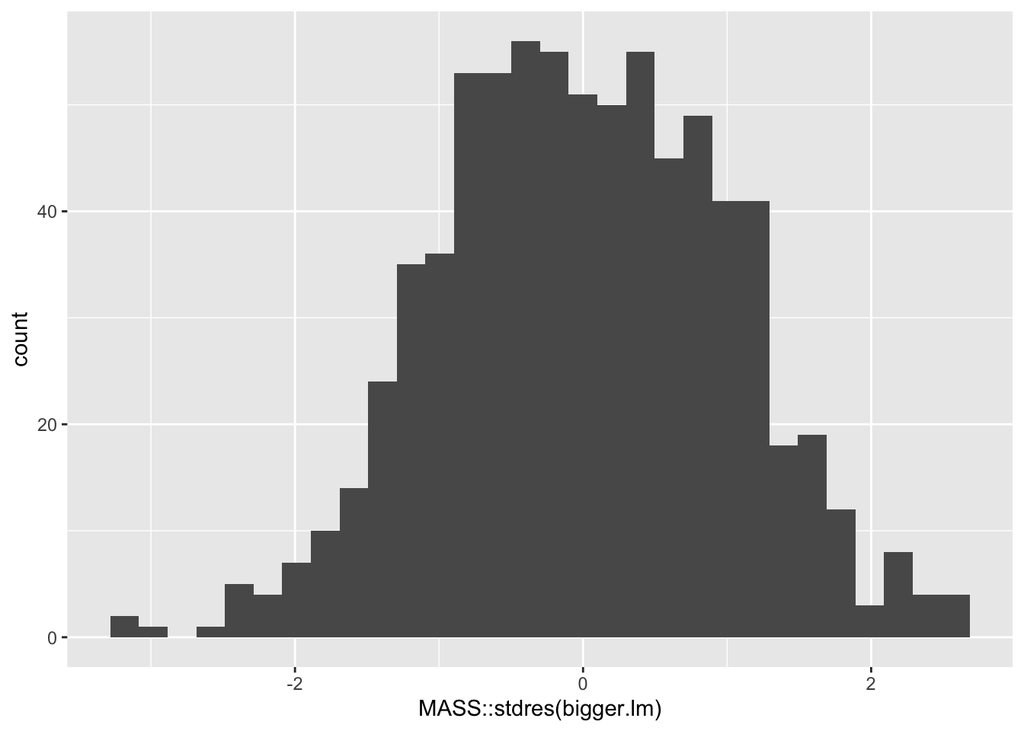

```r
# Independence - think about it
# Normality - Histogram of standardized residuals
standardized.residuals = MASS::stdres(bigger.lm)
ggplot() +
  geom_histogram(mapping = aes(x = MASS::stdres(bigger.lm) ))
```

```r
# KS Test
ks.test(standardized.residuals, "pnorm")
```

```
##
##  One-sample Kolmogorov-Smirnov test
##
## data:  standardized.residuals
## D = 0.024779, p-value = 0.7421
## alternative hypothesis: two-sided
```

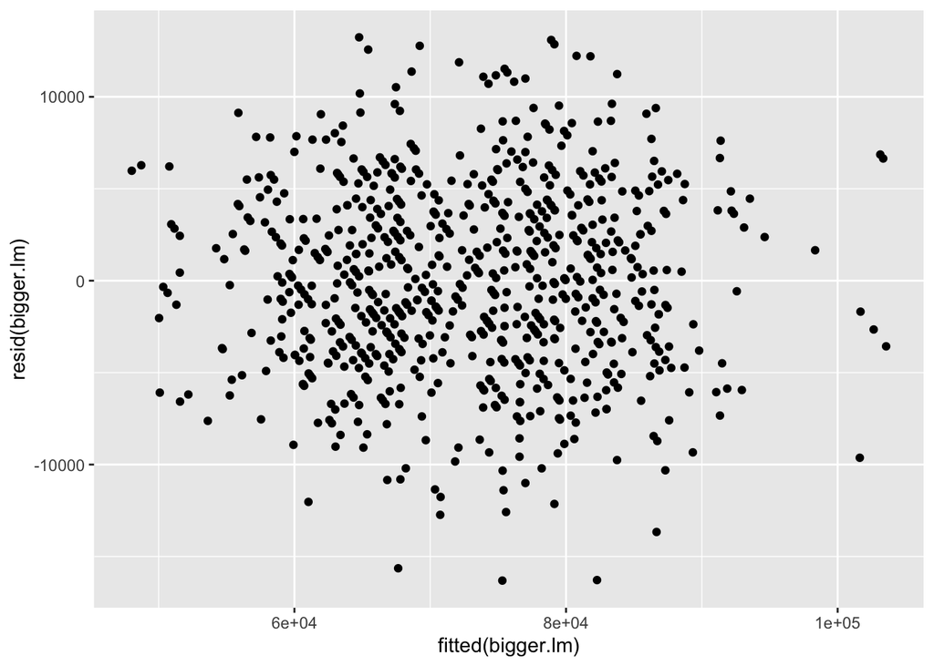

```r
# Equal Variance - BP test or scatterplot of the standardized fitted vs. residuals
ggplot() +
  geom_point(mapping = aes(x = fitted(bigger.lm), y = resid(bigger.lm) ))
```

```r
lmtest::bptest(bigger.lm)
```

```
##
##  studentized Breusch-Pagan test
##
## data:  bigger.lm
## BP = 29.23, df = 32, p-value = 0.6075
```

Linearity - looks good.

Independence - Can assume independence.

Normality - looks normal. Results from the KS test indicate that the standardized residuals follow a normal distribution because of the hi p-value (failing to reject that it is not normal).

```r
new.x = data.frame(GPA = 3.5, Gen = "M", MajorCategory = "Computers & Mathematics")
predict.lm(salary.lm, newdata=new.x, interval="prediction", level=0.97)
```

```
##       fit      lwr      upr
## 1 89752.1 77822.28 101681.9
```

#### 7. For the Computers and Mathematics major category, perform a general linear hypothesis test that women, on average, earn less salary than men (for the same GPA). State your hypotheses, p-value and conclusion. If this test is significant, report and estimate a 95% confidence interval for how much more men earn than women in that major category.

```r
# math and computers, male, 3.0 gpa prediction
men <- matrix(c(1,0,0,0,0,1,0,0,0,0,0,0,0,0,0,0,1,3.0), nrow = 1)
women <- matrix(c(1,0,0,0,0,1,0,0,0,0,0,0,0,0,0,0,0,3.0), nrow = 1)
diff <- men - women  # if positive, then men make more money
ht <- multcomp::glht(full.lm, linfct=diff, alternative="two.sided")
summary(ht)
```

```
##
##   Simultaneous Tests for General Linear Hypotheses
##
## Fit: lm(formula = Salary ~ ., data = salary)
##
## Linear Hypotheses:
##        Estimate Std. Error t value Pr(>|t|)
## 1 == 0     5932        401   14.79   <2e-16 ***
## ---
## Signif. codes:  0 '***' 0.001 '**' 0.01 '*' 0.05 '.' 0.1 ' ' 1
## (Adjusted p values reported -- single-step method)
```

```r
confint(ht, level=0.95)
```

```
##
##   Simultaneous Confidence Intervals
##
## Fit: lm(formula = Salary ~ ., data = salary)
##
## Quantile = 1.9632
## 95% family-wise confidence level
##
##
## Linear Hypotheses:
##        Estimate  lwr       upr
## 1 == 0 5931.6270 5144.3019 6718.9520
```

```r
# t(pred) %*% beta_hat
```

Null Hypothesis: Women and men of the Math & Computers Major with the same GPA will on average have the same salary.

P-value: <2e-16

I conclude that because of the low p-value of <2e-16, men on average in the Math and Computers major earn a statistically significant higher salary than women of the same major and GPA.

95% Confidence interval: I am 95% confident that on average, males will earn between $5,144.30 and $6,718 more than their female counterpart from the Math & Computers major with the same GPA.

#### 8. Using predict.lm() and your fitted model, predict your salary and report an associated 95% prediction interval. Interpret this interval in context.

```r
predict.lm(bigger.lm, newdata = data.frame(MajorCategory = "Computers & Mathematics", Gen = "M", GPA = 3.31), interval = "prediction", level = 0.95)
```

```
##        fit     lwr      upr
## 1 89983.22 79325.6 100640.8
```

I predict that my salary will be $89,983.22. I am 95% confident that my salary will fall between $79,325.60 and $100,640.80.

#### 9. If we wish to use our model for prediction as we did in #8, we should verify how accurate our predictions are via cross-validation. Conduct a leave-one-out cross validation of the salary data. Report your average RPMSE along with the average prediction interval width. Comment on whether you think your predictions are accurate or not.

```r
# Leave-one-out cross validation

n <- nrow(salary)
# placeholder for storing the i-th prediction
preds <- rep(0, n)
wid <- rep(0, n)
bias <- rep(0, n)
rpmse <- rep(0, n)
cvg <- rep(0, n)
for(i in 1:n) {
    dataf.train <- salary[-i, ]
    dataf.test <- salary[i, ]
    lm.fit <- lm(Salary ~ MajorCategory + GPA + Gen + Gen:MajorCategory, data=dataf.train)

    ## Generate predictions for the test set
    my.preds <- predict.lm(lm.fit, dataf.test, interval = "prediction")

    ## Calculate bias
    bias[i] <- mean(my.preds[,'fit'] - dataf.test[['Salary']])

    ## Calculate RPMSE
    rpmse[i] <- (dataf.test[['Salary']] - my.preds[,'fit'])^2 %>% mean() %>% sqrt()

    ## Calculate Coverage
    cvg[i] <- ((dataf.test[['Salary']] > my.preds[,'lwr']) & (dataf.test[['Salary']] < my.preds[,'upr'])) %>% mean()

    ## Calculate Width
    wid[i] <- (my.preds[,'upr'] - my.preds[,'lwr']) %>% mean()
}
mean(rpmse)
```

```
## [1] 4358.084
```

```r
mean(wid)
```

```
## [1] 21013.43
```

Average RPMSE: $4,358.084

Average prediction interval width $21,013.43

I think my predictions are accurate because the root predicted mean square error is only $4,358.084, which is the average distance in amount of money that my predictions were from the actual salary. When thinking of a yearly salary, $4,358 is a very small amount and equates to an error of only $2 an hour, when working a 40 hour work week. This makes my predictions very accurate.